# Toronto’s libraries and languages

Nicholas Field

2018-08-26

# Introduction

Toronto has a reputation for multiculturalism and multilingualism, so this report is an exploration of language in Toronto. Specifically, this report combines census data with open data from the Toronto Public Library to discover which branches best serve multilingual communities, and how that maps onto Toronto’s language communities.

This report was created as part of the “Introduction to R for Journalists” course, offered by Andrew Tran and the Knight Center for Journalism in the Americas. As such, this entire report, including text markdown, data analysis, graphing, and mapping, was completed using R. The files can be downloaded from my Github page, and you can run the script to produce the same results. I have included the code I used for each section, with extensive comments explaining what each step does. This is necessary for transparency and reproducibility.

The following maps and graphs combine 2016 Canadian census data with 2017 Toronto Public Library circulation data. In both cases, these are the most recent available data sets. While library data from 2016 exists, I am using the more recent data because this report is meant to inform current policy decisions.

## Contact information

Please feel free to write me with suggestions, corrections, or feedback!

Email: nicholaskenjifield@gmail.com

Github: https://github.com/nkfield/

Twitter: @nk_field

## Note

If you just want the results (graphs, maps, and tabular data) from the following code, just run the script “run_all.R” in the main project directory, and sit back. Let me caution you that one of the census files it will download is ~130 MB zipped, and ~1.3 GB unzipped, though I provide a workaround below using the files packaged with this project.

## Accessibility

Graphs and maps can, depending on the colour schemes their creators chose, be inaccessible to people with different kinds of colour blindness. The maps in this report all use the [Cividis colour palette](https://www.scientificamerican.com/article/end-of-the-rainbow-new-map-scale-is-more-readable-by-people-who-are-color-blind/?sf195206045=1), which has been scientifically optimised for information preservation across many forms of colour blindness and sightedness. Cividis is available as part of the part of the [Viridis package](https://cran.r-project.org/web/packages/viridis/vignettes/intro-to-viridis.html).

## Sources

All data used in this report are open and freely available for use, provided that attribution is given. I have relied on federal (Canadian) and municipal (Torontonian) open data sets. Each graph and map lists their sources, and here are all of the sources used in this report:

*Toronto Public Library Open Data*

opendata.tpl.ca/

“Branch Information - Census Tracts” https://opendata.tpl.ca/data/Branch_Information/Branch_Census_Tracts.csv

“Circulation - Circulation by Language Group” https://opendata.tpl.ca/data/Circulation/Circulation_by_Language_Group.csv

*Statistics Canada | Statistique Canada*

www12.statcan.gc.ca/

“Census metropolitan areas, tracted census agglomerations and census tracts” from the 2016 Census Profile: https://www12.statcan.gc.ca/census-recensement/2016/dp-pd/prof/details/download-telecharger/comp/GetFile.cfm?Lang=E&TYPE=CSV&GEONO=043

*Open Government, Government of Canada | Governement du Canada* open.canada.ca/

“Census Tracts, Digital Boundary File - 2016 Census”

## Terminology

*Catchment population*: The population which a particular Toronto Public Library branch aims to serve. It is defined in terms of census tracts, and thus in geographic terms.

*Census Tract:* One of basic geographic units of the Canadian national census until 2016, when it was aggregated with other units. It originally comprising roughly 5000 people, though that can vary considerably after a tract is formed. By 2016, some census tracts in Toronto are defunct, but they are how the Toronto Public Library tracks the catchment population each branch serves.

*Circulation:*: The Toronto Public Library’s term for the recorded borrowing of materials. This term encompasses all library materials that can be borrowed (e.g. circulating books and DVDs, but not in-library reference works). I believe that if the same book is borrowed three times in 2018, then it counts three times for circulation records. The key issue to note here is that circulation does not equal collections; some materials might be used frequently, while others might be untouched. Circulation also does not record in-library usage, hence some branches (e.g. the almost non-circulating Arthur Conan Doyle collection, which has been excluded from this report), report zero or almost zero circulation.

*Multilingual:* The Toronto Public Library’s designation for any materials (e.g books, DVDs, audiobooks) which are in languages other than English or French.

*StatCan:* Statistics Canada, the official national source for Canadian statistics, including censuses. This report uses the most recent data set, which is from 2016.

*TPL:* the Toronto Public Library. They publish most of their data annually, meaning that the most recent data are from 2017, except for materials directly relating to the 2016 Canadian census.

## Language

As this report draws on Canadian and Torontonian data, and discusses language use, it unapologetically uses Canadian English spellings. Sorry, eh?

## Thanks

This report grew out of coursework for the course “Introduction to R for Journalists,” offered by the Knight Center for Journalism in the Americas. Many thanks to Andrew Tran, the course instructor, for designing the course, providing feedback, and for suggesting the accessible Cividis colour palette. Thanks also to the course assistant Ryan Sagare. Greg Saulmon, Paula Jennings, and especially Clara Engel provided feedback and suggestions on the graphs and maps in this report, so they all have my gratitude.

# Part 0: Loading R libraries

We will use these libraries to clean, process, graph, and map the data.

```r
# Step 0: Load libraries
# if you do not have these libraries installed, please uncomment and run the following:
# install.packages("dplyr")
# install.packages("forcats")
# install.packages("ggplot2")
# install.packages("readr")
# install.packages("scales")
# install.packages("sf")
# install.packages("tidyr)
# install.packages("viridis")
library(dplyr)
library(forcats)
library(ggplot2)
library(readr)
library(scales)
library(sf)
library(tidyr)
library(viridis)
```

# Part 1: Cleaning the basic data

We begin by downloading, cleaning, and processing data, including the census tract shapefiles. We’ll keep only those census tracts serviced by the Toronto Public Library, so that our final maps don’t have massive greyed-out zones without data.

```r
# Step 1: Acquire and clean data
# get Toronto census tracts shapefile
# though let's avoid downloading it if you already have the full project downloaded
if (!file.exists("raw_data/lct_000a16a_e.shp")) {
  dir.create("raw_data", showWarnings = F)
  temp <- tempfile()
  download.file("http://www12.statcan.gc.ca/census-recensement/2011/geo/bound-limit/files-fichiers/2016/lct_000a16a_e.zip", temp)
  unzip(temp, exdir = "raw_data", overwrite = T)
  unlink(temp)
}
canada_census_tract_location <- "raw_data/lct_000a16a_e.shp"
canada_data <- st_read(canada_census_tract_location)
```

```r
# filtering all Canadian census tracts for just Torontonian tracts
canada_toronto <- filter(canada_data, CMANAME=="Toronto")

# modifying the data type to enable joining later
canada_toronto <- mutate(canada_toronto, CTNAME2 = as.numeric(as.character(CTNAME)))

# Census Tracts serviced by the TPL
if (!file.exists("raw_data/Branch_Census_Tracts.csv")) {
  dir.create("raw_data", showWarnings = F)
  download.file("https://opendata.tpl.ca/data/Branch_Information/Branch_Census_Tracts.csv", "raw_data/Branch_Census_Tracts.csv")
}

# Load the branch census tracts
tpl_census_tracts <- read_csv("raw_data/Branch_Census_Tracts.csv", skip=1)
#filter out branch that has no specific census tract
tpl_census_tracts <- tpl_census_tracts[1:572, 1:3]
tpl_census_tracts$`Census Tract` <- as.numeric(as.character(tpl_census_tracts$`Census Tract`))

# save this cleaned data frame
write_csv(tpl_census_tracts, "output_data/tpl_census_tracts_cleaned.csv")

# join TPL-serviced census tracts to total Torontonian ones
tpl_join <- left_join(canada_toronto, tpl_census_tracts, by=c("CTNAME2"="Census Tract"))

# Filter out census tracts not served by TPL branches
tpl_join <- tpl_join %>% filter(!is.na(ID))

# Add multilingual circulation of TPL holdings
# First, download and import the appropriate csv
if (!file.exists("raw_data/Circulation_by_Language_Group.csv")) {
  dir.create("raw_data", showWarnings = F)
  download.file("https://opendata.tpl.ca/data/Circulation/Circulation_by_Language_Group.csv", "raw_data/Circulation_by_Language_Group.csv")
}

tpl_circulation <- read_csv("raw_data/Circulation_by_Language_Group.csv", skip=3)

# Selecting just the most recent data, from 2017
tpl_circulation <- tpl_circulation[1:15]

# Selecting just the totals for each language, ignoring literacy level
tpl_circulation <- select(tpl_circulation, ID, "Branch Name", Tier, "Total ENG", "Total FRE", "Total MLC", "All Languages")
# Note: all languages other than English and French are condensed into "Multilingual"

# Then, clean the data further by keeping only neighbourhood library branches (NL),
# District Library branches (DL), and Reference and Research branches (RR)
tpl_circulation <- filter(tpl_circulation, Tier %in% c("NL", "DL", "RR"))

# Trimming to remove RR branches that are non-circulating collections
tpl_circulation <- filter(tpl_circulation, ID!= "MC")
tpl_circulation <- filter(tpl_circulation, ID!= "OC")

# Trimming to remove RR "branches" that multiple or ambiguous geographic areas,
# e.g. bookmobiles, interlibrary loan service, and phone services
tpl_circulation <- filter(tpl_circulation, ID!= "AL")
tpl_circulation <- filter(tpl_circulation, ID!= "IL")

# Convert totals to numeric data
tpl_circulation$`Total ENG` <- as.numeric(tpl_circulation$`Total ENG`)
tpl_circulation$`Total FRE` <- as.numeric(tpl_circulation$`Total FRE`)
tpl_circulation$`Total MLC` <- as.numeric(tpl_circulation$`Total MLC`)
tpl_circulation$`All Languages` <- as.numeric(tpl_circulation$`All Languages`)

# Create a column for percent of multilingual circulation
tpl_circulation <- mutate(tpl_circulation, percent_MLC = round((`Total MLC` / `All Languages` * 100), digits = 1))
tpl_circulation <- arrange(tpl_circulation, desc(tpl_circulation$percent_MLC))

# Save this modified data frame
write_csv(tpl_circulation, "output_data/tpl_circulation_mlc.csv")

# Join multilingual circulation data to Toronto census tracts
tpl_circulation[29,2] <- "Dufferin St Clair"
tpl_circulation[25,2] <- "Parliament"
tpl_circulation[12,2] <- "Lillian H Smith"
tpl_circulation[47,2] <- "North York Central"
tpl_circulation[67,2] <- "Mimico"
tpl_circulation[43,2] <- "Maria A Shchuka"
tpl_circulation[64,2] <- "Oakwood Village"
tpl_circulation[92,2] <- "Annette"
tpl_circulation[73,2] <- "St Clair Silverthorn"
tpl_circulation[90,2] <- "Swansea"
tpl_join_pmlc <- left_join(tpl_join, tpl_circulation, by=c("ID", "Branch Name"))
tpl_join_pmlc <- mutate(tpl_join_pmlc, percent_MLC_c = percent_MLC/100)
write_csv(tpl_join_pmlc, "output_data/tpl_join_pmlc.csv")
```

# Part 2: Graphing multilingual circulation

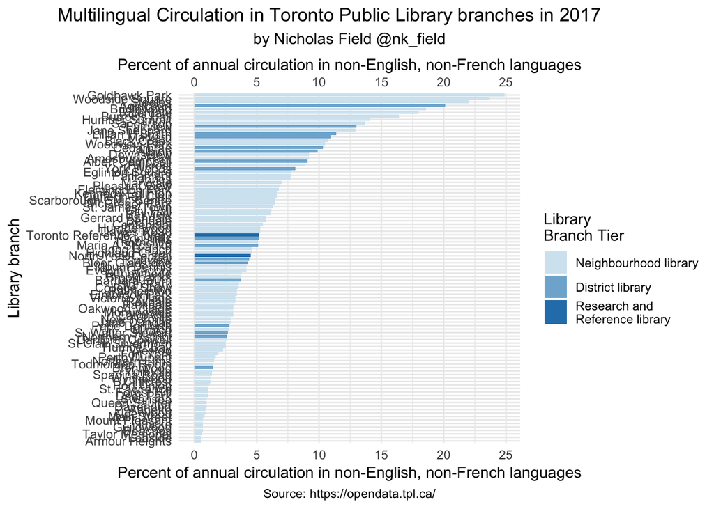

```r
# Step 2: Graphing
# Make plot, from highest percent multilingual circulation to lowest,
# and with coord_flip, for tidiness
# and identifying branch type by colour,
# with colours that should be accessible for colourblind readers
ggplot(data = tpl_circulation, aes(x=fct_reorder(`Branch Name`, percent_MLC), y = percent_MLC, fill=Tier)) +
  geom_bar(stat="identity") +
  coord_flip() +
  theme_minimal() +
  labs(x="Library branch", y="Percent of annual circulation in non-English, non-French languages", title="Multilingual Circulation in Toronto Public Library branches in 2017", subtitle="by Nicholas Field @nk_field", caption="Source: https://opendata.tpl.ca/") +
  scale_fill_manual(values=c("#7fb3d5", "#d4e6f1", "#2980b9"), name="Library\nBranch Tier", breaks=c("NL", "DL", "RR"), labels=c("Neighbourhood library", "District library", "Research and\nReference library")) +
  theme(plot.title = element_text(hjust=0.6), plot.caption = element_text(hjust=0.5), plot.subtitle = element_text(hjust=0.5)) +
  scale_y_continuous(sec.axis = dup_axis())
```

```r
# Save with resizing for legibility
ggsave("output_data/tpl_multilingual_graph.png", width=20, height=30, units="cm")
```

Note: The branch names are squashed together when this graph is viewed within this report, but if you download it and view it at its full size, it is legible.

I ordered the branches in descending rank of their multilingual circulation, and colour-coded them according to the tier of library. Duplicating the X (actually Y) axis allows for greater readability. Please note that I excluded some of the TPL’s circulation services, specifically those that do not correspond to physical library branches, from this graph. (For more information on this issue, see Part 3, below.)

# Part 3: Mapping multilingual circulation

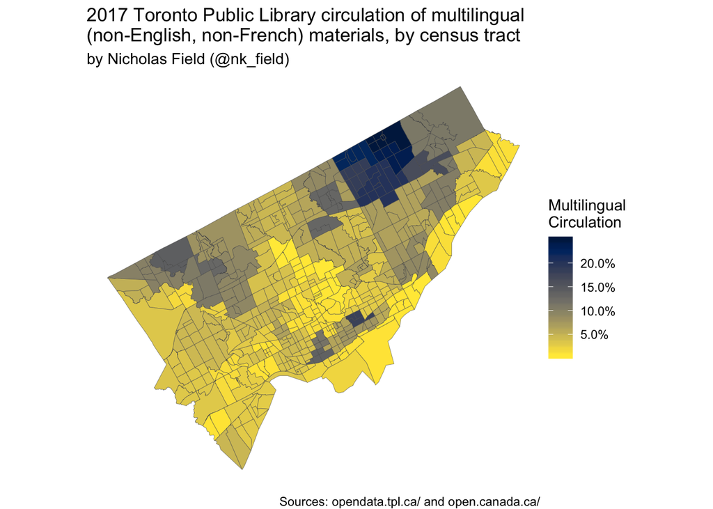

```r
# Step 3: Mapping
ggplot(canada_toronto) +
  geom_sf(data=tpl_join_pmlc, aes(fill = percent_MLC_c), size=.1) +
  scale_fill_viridis(label=percent, option="cividis", direction = -1, name="Multilingual\nCirculation") +
  labs(title = "2017 Toronto Public Library circulation of multilingual\n(non-English, non-French) materials, by census tract", subtitle = "by Nicholas Field (@nk_field)", caption = "Sources: opendata.tpl.ca/ and open.canada.ca/") +
  theme(plot.subtitle = element_text(hjust=0.5)) +
  theme_void() +
  coord_sf(datum = NA)
```

```r
ggsave("output_data/tpl_multilingual_map.png", width=20, height=16, units="cm")
```

Caveats: While the majority of the Toronto Public Library’s circulation data can be mapped, a significant minority refer to branches which serve the entire city (e.g. the Reference Library), to “branches” with multiple and mobile locations (Toronto’s bookmobiles), or to services which are location aspecific (e.g. the library hotline, which allows for holds and lending services). These are important parts of Toronto’s public library infrastructure that I could not place on a map.

# Part 4: Adding Canadian census data

```r
# Step 4: Multilingual census tract information
# Warning! This is a huge file (~ 130 MB zipped, ~1.3 GB unzipped). Downloading and processing may take some time.
# If you want to avoid downloading this file, skip ahead to SKIP_ALL_THAT below

# Census metropolitan areas, tracted census agglomerations and census tracts

if (!file.exists("raw_data/98-401-X2016043_English_CSV_data.csv")) {
  dir.create("raw_data", showWarnings = F)
  temp <- tempfile()
  download.file("https://www12.statcan.gc.ca/census-recensement/2016/dp-pd/prof/details/download-telecharger/comp/GetFile.cfm?Lang=E&TYPE=CSV&GEONO=043", temp)
  unzip(temp, exdir = "raw_data", overwrite = T)
  unlink(temp)
}

canada <- read_csv("raw_data/98-401-X2016043_English_CSV_data.csv")

# just the Toronto data, please!
# specifying rows for Toronto census tracts 1:802.2, which are the tracts serviced by the TPL
toronto <- canada[4646798:7136472,]
# removing other irrelevant information
toronto <- toronto %>% filter(GEO_NAME!="Toronto")
toronto <- toronto %>% select(-DATA_QUALITY_FLAG, -GNR, -GNR_LF, -`Notes: Profile of Census Tracts (2247)`, -ALT_GEO_CODE, -GEO_LEVEL, -CENSUS_YEAR, -`GEO_CODE (POR)`, -`Dim: Sex (3): Member ID: [2]: Male`, -`Dim: Sex (3): Member ID: [3]: Female`)

# Please note that census tract 006.00 has no population data, though it has a geographic region associated with it.
# Likewise tract 205.00 has a small population (149) but no other data associated with it.

# saving output
write_csv(toronto, "output_data/toronto2016ct.csv")

# Or, SKIP_ALL_THAT and uncomment and run this instead
# toronto <- read_csv("output_data/toronto2016ct.csv")

# Selecting data regarding total population and use of languages other than English and French
#   1 == total population of a given census tract
# 104 == pop with no knowledge of either English or French
# 117 == pop with mother tongue which is neither English or French
# 386 == pop with language most spoken at home being neither English or French
# 654 == pop with other languages spoken at home (e.g. second or third most spoken at home) which are neither Eng or Fre
toronto_lang_pop <- toronto %>% filter(`Member ID: Profile of Census Tracts (2247)` == 1 | `Member ID: Profile of Census Tracts (2247)` == 104 | `Member ID: Profile of Census Tracts (2247)` == 117 | `Member ID: Profile of Census Tracts (2247)` == 386 | `Member ID: Profile of Census Tracts (2247)` == 654)
toronto_lang_pop <- select(toronto_lang_pop, -`DIM: Profile of Census Tracts (2247)`)
names(toronto_lang_pop)[3]<-"population"

# tidying data
toronto_lang_pop = spread(toronto_lang_pop, `Member ID: Profile of Census Tracts (2247)`, population)
names(toronto_lang_pop) <- c("CT_GEO", "total_pop", "know_no_ef", "mother_not_ef", "home_not_ef", "home_other_not_ef")
toronto_lang_pop <- mutate(toronto_lang_pop, CT_GEO2 = as.numeric(as.character(CT_GEO)))
toronto_lang_pop <- select(toronto_lang_pop, -CT_GEO)

# saving output
write_csv(toronto_lang_pop, "output_data/toronto2016lang_pop_ct.csv")

# join to data above
tpl_join_pmlc_ct <- left_join(tpl_join_pmlc, toronto_lang_pop, by=c("CTNAME2"="CT_GEO2"))

# create percentages
tpl_join_pmlc_ct <- mutate(tpl_join_pmlc_ct, percent_know_no_ef = round((know_no_ef / total_pop), digits = 3))
tpl_join_pmlc_ct <- mutate(tpl_join_pmlc_ct, percent_mother_not_ef = round((mother_not_ef / total_pop), digits = 3))
tpl_join_pmlc_ct <- mutate(tpl_join_pmlc_ct, percent_home_not_ef = round((home_not_ef / total_pop), digits = 3))
tpl_join_pmlc_ct <- mutate(tpl_join_pmlc_ct, percent_home_other_not_ef = round((home_other_not_ef / total_pop), digits = 3))
tpl_join_pmlc_ct <- mutate(tpl_join_pmlc_ct, percent_home_total_not_ef = percent_home_not_ef + percent_home_other_not_ef)
tpl_join_pmlc_ct <- mutate(tpl_join_pmlc_ct, gap_know_no_ef = (percent_MLC_c - percent_know_no_ef))
```

# Part 5: Mapping Toronto’s population that does not speak English or French

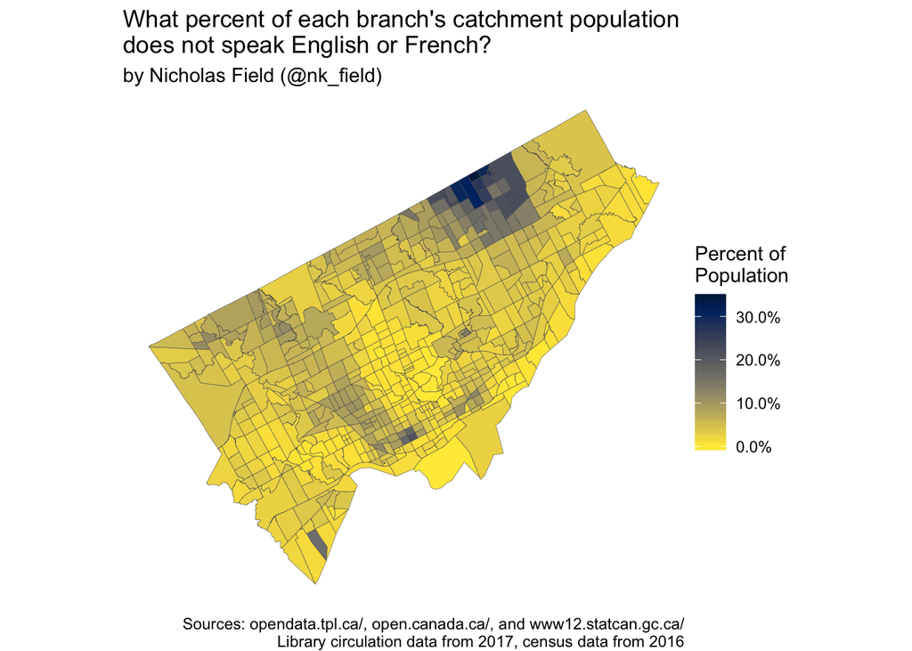

```r
# Step 5: Mapping Toronto's population that does not speak English or French
ggplot(canada_toronto) +
  geom_sf(data=tpl_join_pmlc_ct, aes(fill = percent_know_no_ef), size=.1) +
  scale_fill_viridis(label=percent, option="cividis", direction = -1, name="Percent of\nPopulation") +
  labs(title = "What percent of each branch's catchment population\ndoes not speak English or French?",
       subtitle = "by Nicholas Field (@nk_field)",
       caption = "Sources: opendata.tpl.ca/, open.canada.ca/, and www12.statcan.gc.ca/\nLibrary circulation data from 2017, census data from 2016") +
  theme(plot.title = element_text(hjust=0), plot.subtitle = element_text(hjust=0.5)) +
  theme_void() +
  coord_sf(datum = NA)
```

```r
ggsave("output_data/no_ef_map.png", width=20, height=16, units="cm")
```

In some places, these results match up with library branch catchment areas that have a high multilingual circulation, though that is not always the case. Note that one tract in the Parkdale neighbourhood (southwestern Toronto) lacks census data and therefore appears grey.

# Part 6: Graphing the gap between populations that don’t speak English or French and the libraries that serve them

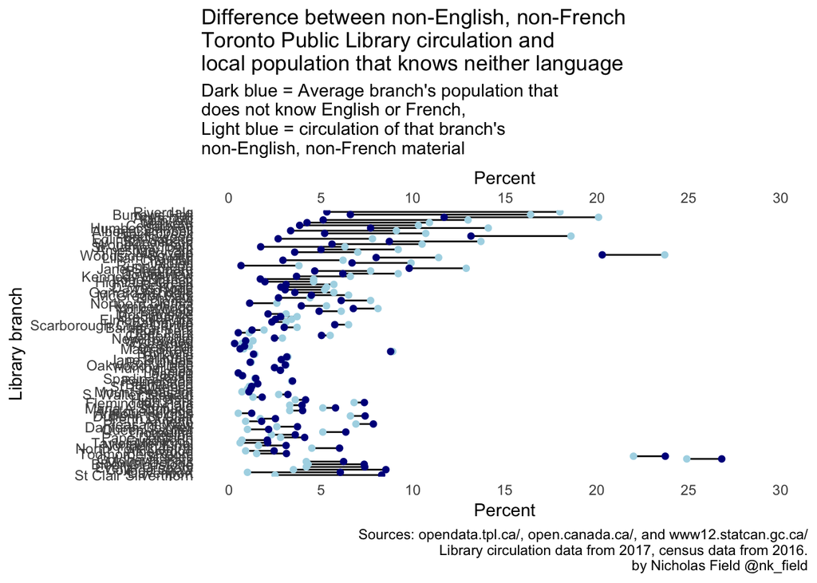

```r
# Step 6: Graphing the gap between populations that don't speak English or French and the libraries that serve them
tpl_join_pmlc_ct2 <- filter(tpl_join_pmlc_ct, total_pop!= 0)
tpl_join_pmlc_ct2 <- filter(tpl_join_pmlc_ct2, CTNAME2 != 205.00)

just_avg_no_ef <- tpl_join_pmlc_ct2 %>% group_by(`Branch Name`) %>% summarise(avg_pc_know_no_ef = round(mean(percent_know_no_ef), digits = 4) * 100, avg_gap = round(mean(gap_know_no_ef), digits = 4) * 100)
avg_join <- left_join(tpl_circulation, just_avg_no_ef, by="Branch Name")
avg_join <- filter(avg_join, `Branch Name` != "Toronto Reference Library")
avg_join <- arrange(avg_join, avg_gap)
ggplot(avg_join) +
  geom_segment(
    aes(x = avg_pc_know_no_ef,
        y = fct_reorder(`Branch Name`, avg_gap),
        xend = percent_MLC,
        yend = fct_reorder(`Branch Name`, avg_gap))) +
  geom_point(aes(x=percent_MLC, y=`Branch Name`), color="light blue") +
  geom_point(aes(x=avg_pc_know_no_ef, y=`Branch Name`), color="dark blue") +
  labs(x="Percent",
       y="Library branch",
       title="Difference between non-English, non-French\nToronto Public Library circulation and\nlocal population that knows neither language",
       subtitle="Dark blue = Average branch's population that\ndoes not know English or French,\nLight blue = circulation of that branch's\nnon-English, non-French material",
       caption="Sources: opendata.tpl.ca/, open.canada.ca/, and www12.statcan.gc.ca/\nLibrary circulation data from 2017, census data from 2016.\nby Nicholas Field @nk_field") +
  theme_minimal() +
  theme(panel.border = element_blank(),
        panel.grid.major = element_blank(),
        panel.grid.minor = element_blank()) +
  scale_x_continuous(breaks=seq(0,30,5), limits=c(0,30), sec.axis = dup_axis())
```

```r
ggsave("output_data/tpl_gap_graph.png", width=20, height=30, units="cm")
```

Note: The branch names are squashed together when this graph is viewed within this report, but if you download it and view it at its full size, it is legible.

The above graph lists the library branches in descending order of the difference between the observed multilingual usage (in terms of circulation) and the percentage of the population who do not speak English or French. For the purposes of this graph, I assume that, at the very least, a branch’s multilingual use should be the same as, or greater than, the percentage of its catchment population that does not speak English or French.

The branches in the upper half of the graph have a higher multilingual circulation than percent of their catchment population that does not speak English of French. The branches in the middle, such as Hillcrest and Yorkville, have matching percentages, while those in the bottom have lower mutlingual circulation percentages than percent of local population that do not speak English or French.

Some branches, such as Steeles and Goldhawk Park, have a relatively high percentage of multilingual circulation and yet still their multilingual circulation is less than their catchment population’s percentage of people who do not speak English or French.

Caveats: Please note that the possibly misleading assumption behind my graph above is that circulation accurately reflects the population a branch serves. We should not assume that all linguistic communities use Toronto’s library branches equally. We should also not assume that a branch with a percent of multilingual circulation equal to the percent of non-English, non-French speakers in its catchment areas is meeting the needs of its linguistically diverse population; there are, of course, many people who know two or more languages, wholly or partially, and thus even a branch where everyone in its catchment population can speak English or French might benefit considerably from materials in additional languages. For evidence of Toronto’s linguistic pluarlity, see Part 8, the map of Torontonians with first languages other than English and French, below. Additionally, the circulation data do not fully express nuanced yet everyday occurances in Toronto, such as an English Language learner, who might not report on a census that they speak English, borrowing English-language materials from a library in order to learn. Finally, the caveats about which circulation data are mappable (see Part 3, above) also apply here.

# Part 7: Mapping the gap

Now let us map the difference between the last two maps, showing which regions have the biggest margin (i.e. excess or gap) between the observed multingual usage (in terms of circulation) and the expected minimum multilingual usage (in terms of population who do not speak English or French):

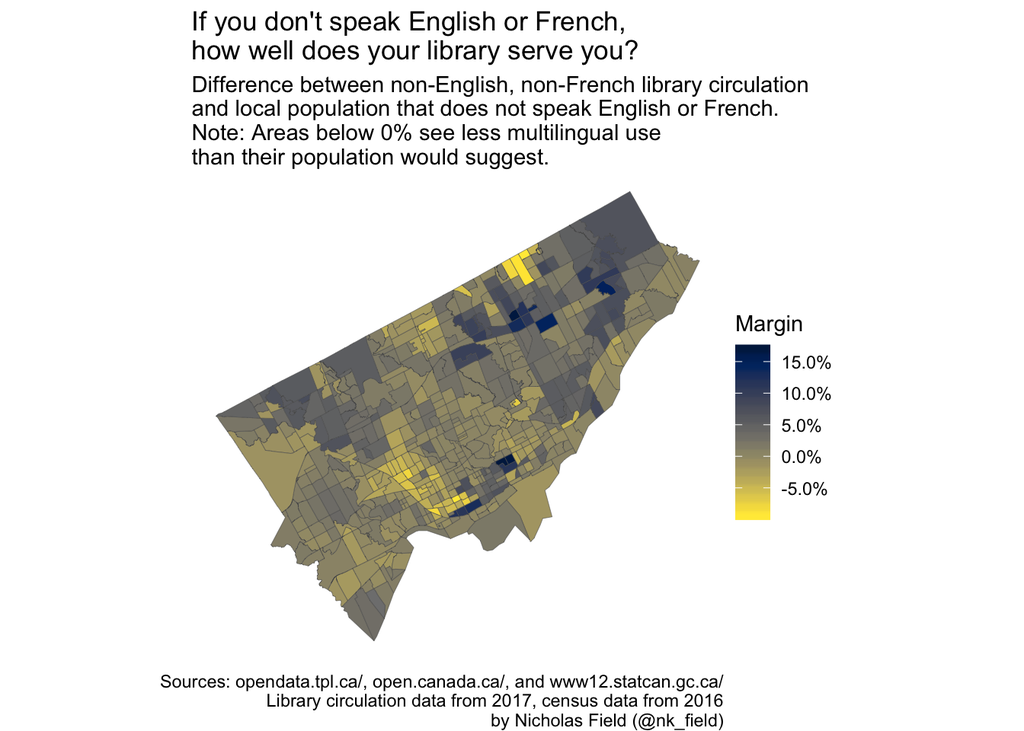

```r
# Step 7: Mapping the gap
# What is the difference between our first and second maps?
ggplot(canada_toronto) +
  geom_sf(data=tpl_join_pmlc_ct, aes(fill = gap_know_no_ef), size=.1) +
  scale_fill_viridis(label=percent, option="cividis", direction = -1, name="Margin") +
  labs(title = "If you don't speak English or French,\nhow well does your library serve you?",
       subtitle = "Difference between non-English, non-French library circulation\nand local population that does not speak English or French.\nNote: Areas below 0% see less multilingual use\nthan their population would suggest.",
       caption = "Sources: opendata.tpl.ca/, open.canada.ca/, and www12.statcan.gc.ca/\nLibrary circulation data from 2017, census data from 2016\nby Nicholas Field (@nk_field)") +
  theme(plot.title = element_text(hjust=0), plot.subtitle = element_text(hjust=0.5)) +
  theme_void() +
  coord_sf(datum = NA)
```

```r
ggsave("output_data/tpl_gap_map.png", width=20, height=16, units="cm")
```

All of the caveats mentioned before apply here, of course. Additionally, note that one tract in the Parkdale neighbourhood (southwestern Toronto) lacks census data and therefore appears grey.

# Part 8: Mapping Torontonians whose first language is not English or French

While the above maps and graphs displayed information about only those people who do not speak either English or French, here we will map something a bit more representative of Toronto’s multilingual population: the percent of people (by census tract) whose first language is not English or French (but who may or may not speak either or both languages.

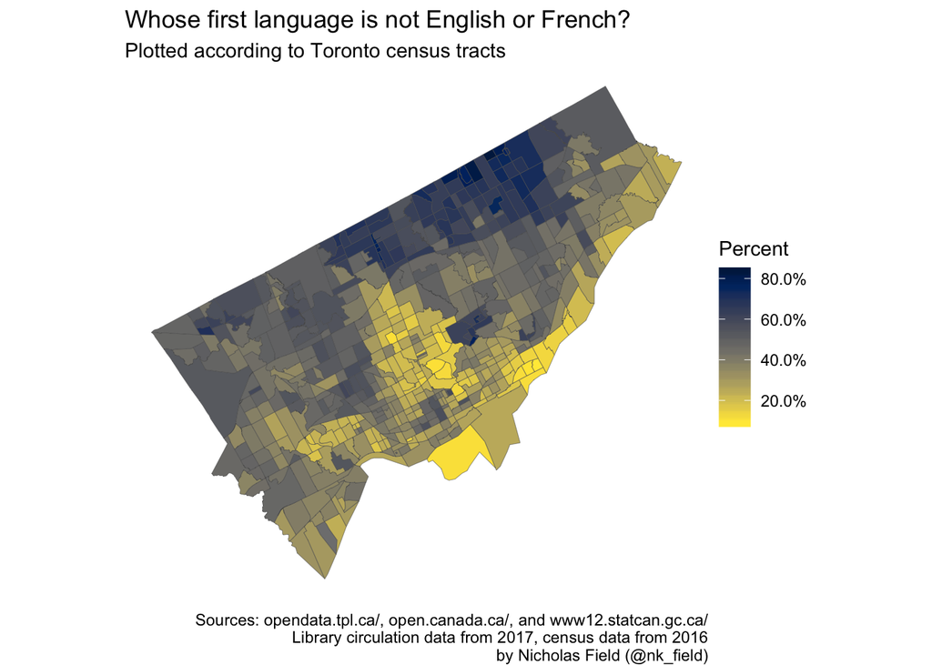

```r
# Step 8: Mapping anyone in Toronto whose first language is not English or French
ggplot(canada_toronto) +
  geom_sf(data=tpl_join_pmlc_ct, aes(fill = percent_mother_not_ef), size=.1) +
  scale_fill_viridis(label=percent, option="cividis", direction = -1, name="Percent") +
  labs(title = "Whose first language is not English or French?",
       subtitle = "Plotted according to Toronto census tracts",
       caption = "Sources: opendata.tpl.ca/, open.canada.ca/, and www12.statcan.gc.ca/\nLibrary circulation data from 2017, census data from 2016\nby Nicholas Field (@nk_field)") +
  theme(plot.title = element_text(hjust=0), plot.subtitle = element_text(hjust=0.5)) +
  theme_void() +
  coord_sf(datum = NA)
```

```r
ggsave("output_data/first_language_map.png", width=20, height=16, units="cm")
```

Some parts of Toronto have 80% of the population knowing a first language other than English or French. Unsurprisingly, these populations are often also areas where libraries have higher levels of people who do not speak either English or French. Happily, these are often also areas that see a high multilingual circulation of library materials. Note that one tract in the Parkdale neighbourhood (southwestern Toronto) lacks census data and therefore appears grey.

# Conclusion

Some directions for future research are to target specific languages, such as Chinese, rather than the broad category of multilingual material. While the Canadian census data are granular enough to support this kind of analysis, the TPL data sets used above are not. There are, however, about 2.5-3.0 GB of catalogue data in MARC format that might provide more detailed information, provided there is a way of converting them into an R-compatible format.

That’s it! Thanks for reading. If you have problems, suggestions, or feedback, feel free to reach out to me at:

Email: nicholaskenjifield@gmail.com

Github: https://github.com/nkfield/

Twitter: @nk_field